# Part 4 - Texting Bans and Car Accidents: Difference-in-Differences

Applied Econometrics, Hebrew University, 2023

Ido Shalom

Ofri Ahiel

Daniel Rodan

Ori Shneor

# Part 1. Setup

## Section 1

```r
# Reading the data.
dat <- read.dta13("data/estdata.dta")

# Computing the number of states.
n_distinct(dat$state, na.rm = TRUE)
```

```
## [1] 51
```

```r
# Computing the number of time periods.
(dat %>% group_by(year) %>% summarise(count = n_distinct(month, na.rm = TRUE)))[2] %>% sum()
```

```
## [1] 48
```

There is 51 states, and 48 time periods in the dataset.

## Section 2

### Sub-section a

```r
# Count the number of NA's for the variable "txmsban".
sum(is.na(dat$txmsban))
```

```
## [1] 89
```

```r
# Count the number of NA's for the variable "laccidentsvso2"
sum(is.na(dat$laccidentsvso2))
```

```
## [1] 0
```

### Sub-section b

```r
# The observations contain NA's for txmsban or for laccidentsvso2 with relevance to state and time.
dat[is.na(dat[c("txmsban","laccidentsvso2")]), c("state", "time")]
```

|  | state | time |
| --- | --- | --- |
| 49 | 2 | 1 |
| 50 | 2 | 2 |
| 51 | 2 | 3 |
| 52 | 2 | 4 |
| 53 | 2 | 5 |
| 54 | 2 | 6 |
| 55 | 2 | 7 |
| 56 | 2 | 8 |
| 57 | 2 | 9 |
| 58 | 2 | 10 |

[output cut: 79 more lines]

### Sub-section c

```r
# Checking Which states have missing time periods.
missing_periods <- which(is.na(dat[c("year", "month")]), arr.ind = TRUE)[,1]

# Display in a small table the states index Which missing time periods.
table(dat[missing_periods,]$state)
```

```
##
##  2  9
## 47 42
```

### Sub-section d

```r
# Removing states 2 and 9 which have missing time periods.
df <- subset(dat, !(state %in% c(2, 9)))
```

# Part 2. Canonical Diff-In-Diff

## Section 1

### Sub-section a

```r
# Finding  the first time period in which State 43 implemented a texting ban.
txt_43 <- arrange(subset(df, state == 43 & txmsban == 1), time)$time[1]
txt_43
```

```
## [1] 31
```

```r
# Creating a new data frame restricted only to states 43 and 25
df_25_43 <- subset(df, state == 25| state == 43)

# Create dummy variable for post
df_25_43$post <- ifelse(df_25_43$time >= txt_43, 1, 0)
```

### Sub-section b

The “No Anticipatory Effects” assumption means that individuals or entities in the treatment group do not anticipate the treatment and change their behavior in anticipation of it. In other words, they do not adjust their actions or outcomes prior to the actual implementation of the treatment.

In our case, we will assume that in the periods before the texting ban implemented in state 43, the citizens of the state did not anticipate the texting ban and therefore, they acted regularly and did not cause any casual effect prior to the implementation in the study.

### Sub-section c

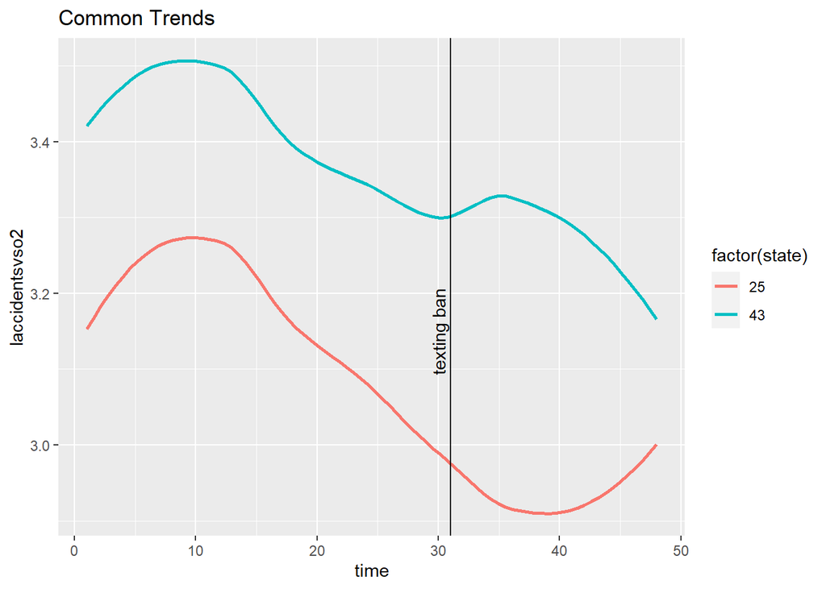

```r
# creating a plot for the two states.
ggplot(df_25_43, aes(time, laccidentsvso2, group=state, color=factor(state)))+
  geom_smooth(se=FALSE)+
  geom_vline(xintercept=txt_43)+
  annotate("text",x = 30,y = 3.15,label = "texting ban",angle = 90)+
  labs(title = "Common Trends")
```

The “Common Trends Assumption” assumes that any differences in outcomes between the two groups after the treatment can be attributed solely to the treatment itself, rather than pre-existing divergent trends.

Based on the plot only,we can see that the “Common Trends Assumption” holds in our case. before the period of the texting ban in state 43, the two states graphs basically parallel over time.

### Sub-section d

$$Y_{it} = \beta_0 + \beta_1 STATE43_i +
\beta_2 POST_t + \beta_3 STATE43_i*POST_t + \epsilon_{it}$$

```r
# Creating dummy variable to extract only state 43 from the data frame.
df_25_43$state43 <- ifelse(df_25_43$state == 43, 1, 0)

# A fully saturated regression model on laccidentsvso2.
model1_a <- lm(laccidentsvso2 ~ state43 + post + state43*post, df_25_43)
summary(model1_a)
```

```
##
## Call:
## lm(formula = laccidentsvso2 ~ state43 + post + state43 * post,
##     data = df_25_43)
##
## Residuals:
##     Min      1Q  Median      3Q     Max
## -0.7313 -0.1582 -0.0116  0.1560  0.4880
##
## Coefficients:
##              Estimate Std. Error t value Pr(>|t|)
## (Intercept)   3.17616    0.04313  73.645  < 2e-16 ***
## state43       0.24784    0.06099   4.063 0.000102 ***
## post         -0.24620    0.07043  -3.496 0.000729 ***
## state43:post  0.11845    0.09960   1.189 0.237404
## ---
## Signif. codes:  0 '***' 0.001 '**' 0.01 '*' 0.05 '.' 0.1 ' ' 1
##
## Residual standard error: 0.2362 on 92 degrees of freedom
## Multiple R-squared:  0.3622, Adjusted R-squared:  0.3414
## F-statistic: 17.42 on 3 and 92 DF,  p-value: 4.899e-09
```

### Sub-section e

```r
# A regression on laccidentsvso2 with the controls that were use by the authors in the paper.
model1_b <- lm(laccidentsvso2 ~ state43 + post + state43*post + lpop + lunemp + permale2 + rgastax, df_25_43)
summary(model1_b)
```

```
##
## Call:
## lm(formula = laccidentsvso2 ~ state43 + post + state43 * post +
##     lpop + lunemp + permale2 + rgastax, data = df_25_43)
##
## Residuals:
##      Min       1Q   Median       3Q      Max
## -0.73410 -0.15898  0.00519  0.15268  0.45337
##
## Coefficients:
##               Estimate Std. Error t value Pr(>|t|)
## (Intercept)   131.9974   123.4573   1.069    0.288
## state43         6.3430     5.8876   1.077    0.284
## post           -0.1352     0.1101  -1.228    0.223
## lpop           -8.0166     7.7970  -1.028    0.307
## lunemp         -0.2402     0.2219  -1.082    0.282
## permale2       -0.1506     0.3358  -0.449    0.655
## rgastax      -925.2231   984.3436  -0.940    0.350
## state43:post    0.2307     0.1455   1.585    0.117
##
## Residual standard error: 0.229 on 88 degrees of freedom
## Multiple R-squared:  0.4267, Adjusted R-squared:  0.3811
## F-statistic: 9.356 on 7 and 88 DF,  p-value: 1.278e-08
```

### Sub-section f

```r
# A regression on laccidentsvso2 with the controls that were use by the authors in the paper and the weights that correspond to the state population.
model1_c <- lm(laccidentsvso2 ~ state43 + post + state43*post + lpop + lunemp + permale2 + rgastax, df_25_43, weights = pop)
summary(model1_c)
```

```
##
## Call:
## lm(formula = laccidentsvso2 ~ state43 + post + state43 * post +
##     lpop + lunemp + permale2 + rgastax, data = df_25_43, weights = pop)
##
## Weighted Residuals:
##      Min       1Q   Median       3Q      Max
## -1849.55  -312.02    18.52   298.28  1135.31
##
## Coefficients:
##               Estimate Std. Error t value Pr(>|t|)
## (Intercept)   115.9793   116.4952   0.996    0.322
## state43         5.6589     5.4564   1.037    0.303
## post           -0.1436     0.1307  -1.099    0.275
## lpop           -7.1058     7.2353  -0.982    0.329
## lunemp         -0.2100     0.2091  -1.004    0.318
## permale2       -0.1040     0.4171  -0.249    0.804
## rgastax      -858.3479   983.1512  -0.873    0.385
## state43:post    0.2115     0.1581   1.338    0.184
##
## Residual standard error: 503.3 on 88 degrees of freedom
## Multiple R-squared:  0.3779, Adjusted R-squared:  0.3284
## F-statistic: 7.637 on 7 and 88 DF,  p-value: 3.483e-07
```

### Sub-section g

```r
# Creating a regressions table for all three previous sub-sections.
stargazer(model1_a, model1_b, model1_c, type = "html", title = "Rsegressions Table", column.labels = c("Model 1", "Model 1 with Controls", "Model 1 with controls and weights"))
```

**Rsegressions Table**

|  | *Dependent variable:* |  |  |
| --- | --- | --- | --- |
|  | laccidentsvso2 |  |  |
|  | Model 1 | Model 1 with Controls | Model 1 with controls and weights |
|  | (1) | (2) | (3) |
| state43 | 0.248*** | 6.343 | 5.659 |
|  | (0.061) | (5.888) | (5.456) |
| post | -0.246*** | -0.135 | -0.144 |
|  | (0.070) | (0.110) | (0.131) |
| lpop |  | -8.017 | -7.106 |
|  |  | (7.797) | (7.235) |
| lunemp |  | -0.240 | -0.210 |
|  |  | (0.222) | (0.209) |
| permale2 |  | -0.151 | -0.104 |
|  |  | (0.336) | (0.417) |
| rgastax |  | -925.223 | -858.348 |
|  |  | (984.344) | (983.151) |
| state43:post | 0.118 | 0.231 | 0.211 |
|  | (0.100) | (0.146) | (0.158) |
| Constant | 3.176*** | 131.997 | 115.979 |
|  | (0.043) | (123.457) | (116.495) |
| Observations | 96 | 96 | 96 |
| R<sup>2</sup> | 0.362 | 0.427 | 0.378 |
| Adjusted R<sup>2</sup> | 0.341 | 0.381 | 0.328 |
| Residual Std. Error | 0.236 (df = 92) | 0.229 (df = 88) | 503.285 (df = 88) |
| F Statistic | 17.416*** (df = 3; 92) | 9.356*** (df = 7; 88) | 7.637*** (df = 7; 88) |
| *Note:* | p<0.1; p<0.05; p<0.01 |  |  |

## Section 2

### Sub-section a

```r
# Creating a dummy variable "post" for every state according to the starting treatment period of state 43.
df$post <- ifelse(df$time >= txt_43, 1, 0)

# Creating dummy variable for "treated" that is equal to 1 if the state ever implemented a text message ban and 0 otherwise.
df$treated <- ifelse(group_by(df, state)$txmsban == 1, 1, 0)

# Creating a table of treated states
treat <- group_by(df, state) %>% summarise(sum(txmsban))

# Creating a dummy variable for treated in the original data frame.
df$treated <- ifelse(df$state %in% treat[which(treat[2] == 0),][[1]], 0 ,1)
```

### Sub-section b

$$Y_{it} = \alpha_0 + \alpha_1 TREATED_i +
\alpha_2 POST_t + \alpha_3 TREATED_i*POST_t + \epsilon_{it}$$

```r
# A fully saturated regression model on laccidentsvso2.
model2 <- lm(laccidentsvso2 ~ treated + post + treated*post, df)
summary(model2)
```

```
##
## Call:
## lm(formula = laccidentsvso2 ~ treated + post + treated * post,
##     data = df)
##
## Residuals:
##      Min       1Q   Median       3Q      Max
## -2.55033 -0.57645  0.08873  0.68564  2.10702
##
## Coefficients:
##              Estimate Std. Error t value Pr(>|t|)
## (Intercept)   2.48860    0.03614  68.852   <2e-16 ***
## treated       0.06173    0.04869   1.268   0.2050
## post         -0.12972    0.05902  -2.198   0.0281 *
## treated:post  0.04151    0.07951   0.522   0.6017
## ---
## Signif. codes:  0 '***' 0.001 '**' 0.01 '*' 0.05 '.' 0.1 ' ' 1
##
## Residual standard error: 0.9286 on 2348 degrees of freedom
## Multiple R-squared:  0.004917,   Adjusted R-squared:  0.003646
## F-statistic: 3.868 on 3 and 2348 DF,  p-value: 0.008982
```

### Sub-section c

$$Y_{it} = \gamma_i + \phi_t + \alpha_3
TREATED_i*POST_t + \epsilon_{it}$$

```r
# A regression on laccidentsvso2 with fixed effects.
model3_a <- lm_robust(laccidentsvso2 ~ treated:post, df,fixed_effects = state+time)
summary(model3_a)
```

```
##
## Call:
## lm_robust(formula = laccidentsvso2 ~ treated:post, data = df,
##     fixed_effects = state + time)
##
## Standard error type:  HC2
##
## Coefficients:
##              Estimate Std. Error t value Pr(>|t|) CI Lower CI Upper   DF
## treated:post  0.04151    0.03008    1.38   0.1678 -0.01749   0.1005 2255
##
## Multiple R-squared:  0.867 , Adjusted R-squared:  0.8613
## Multiple R-squared (proj. model):  0.0008677 ,   Adjusted R-squared (proj. model):  -0.04167
## F-statistic (proj. model): 1.904 on 1 and 2255 DF,  p-value: 0.1678
```

we have notice that the standard error of the estimate on the interaction term in regression sub-section c, is smaller compered to the one on sub-section b (makes sense, because it’s robust standard errors).

### Sub-section d

$$Y_{it} = \gamma_i + \phi_t + \alpha_1
TREATED_i + \alpha_2 POST_t + \alpha_3 TREATED_i*POST_t +
\epsilon_{it}$$

```r
# Regression on laccidentsvso2 with fixed effects and dummies.
model4 <- lm_robust(laccidentsvso2 ~ treated + post + treated*post,  df,fixed_effects = state+time)
summary(model4)
```

```
## 2 coefficients  not defined because the design matrix is rank deficient
```

```
##
## Call:
## lm_robust(formula = laccidentsvso2 ~ treated + post + treated *
##     post, data = df, fixed_effects = state + time)
##
## Standard error type:  HC2
##
## Coefficients: (2 not defined because the design matrix is rank deficient)
##              Estimate Std. Error t value Pr(>|t|) CI Lower CI Upper   DF
## treated            NA         NA      NA       NA       NA       NA   NA
## post               NA         NA      NA       NA       NA       NA   NA
## treated:post  0.04151    0.03008    1.38   0.1678 -0.01749   0.1005 2255
##
## Multiple R-squared:  0.867 , Adjusted R-squared:  0.8613
## Multiple R-squared (proj. model):  0.0008677 ,   Adjusted R-squared (proj. model):  -0.04167
## F-statistic (proj. model):    NA on 1 and 2255 DF,  p-value: NA
```

The reason why we did not include them is because, When we try to add the dummy variables to the model with fixed effect,we actually putting into the regression equation two variables which is a linear “equation” of one another, and we will get the same results as in model 3.it creates full multicollinearity with $\phi$ and $\gamma$.

### Sub-section e

```r
# A regression on laccidentsvso2 with fixed effects, controls, and weights.
model3_b <- lm_robust(laccidentsvso2 ~ treated:post + lpop + lunemp + permale2 + rgastax, df, fixed_effects = state + time, weights = pop)
summary(model3_b)
```

```
##
## Call:
## lm_robust(formula = laccidentsvso2 ~ treated:post + lpop + lunemp +
##     permale2 + rgastax, data = df, weights = pop, fixed_effects = state +
##     time)
##
## Weighted, Standard error type:  HC2
##
## Coefficients:
##                Estimate Std. Error  t value Pr(>|t|)   CI Lower   CI Upper   DF
## lpop          -0.209429    0.85792 -0.24411  0.80717   -1.89182  1.473e+00 2251
## lunemp        -0.180115    0.09184 -1.96112  0.04999   -0.36022 -9.088e-06 2251
## permale2      -0.001374    0.02651 -0.05185  0.95865   -0.05335  5.060e-02 2251
## rgastax      -41.146955   35.11325 -1.17184  0.24139 -110.00468  2.771e+01 2251
## treated:post   0.003946    0.02688  0.14681  0.88329   -0.04876  5.665e-02 2251
##
## Multiple R-squared:  0.9002 ,    Adjusted R-squared:  0.8958
## Multiple R-squared (proj. model):  0.004745 ,    Adjusted R-squared (proj. model):  -0.03947
## F-statistic (proj. model): 1.438 on 5 and 2251 DF,  p-value: 0.2074
```

# Part 3. Staggered Diff-In-Diff

## Section 1

$$Y_{it} = \gamma_i + \phi_t + BAN_{it} +
\epsilon_{it}$$

```r
# A regression on laccidentsvso2 with txmsban,controls and fixed effects.
model5 <- lm_robust(laccidentsvso2 ~txmsban + lpop + lunemp + permale2 + rgastax,  df,fixed_effects = state+time,weights = pop)
summary(model5)
```

```
##
## Call:
## lm_robust(formula = laccidentsvso2 ~ txmsban + lpop + lunemp +
##     permale2 + rgastax, data = df, weights = pop, fixed_effects = state +
##     time)
##
## Weighted, Standard error type:  HC2
##
## Coefficients:
##           Estimate Std. Error t value Pr(>|t|)   CI Lower CI Upper   DF
## txmsban   -0.03672    0.02445 -1.5018  0.13330   -0.08466  0.01123 2251
## lpop      -0.38213    0.85825 -0.4452  0.65619   -2.06518  1.30092 2251
## lunemp    -0.19084    0.09193 -2.0758  0.03802   -0.37112 -0.01056 2251
## permale2  -0.01317    0.02693 -0.4892  0.62478   -0.06598  0.03963 2251
## rgastax  -36.25682   34.83051 -1.0410  0.29801 -104.56009 32.04645 2251
##
## Multiple R-squared:  0.9003 ,    Adjusted R-squared:  0.8959
## Multiple R-squared (proj. model):  0.006079 ,    Adjusted R-squared (proj. model):  -0.03808
## F-statistic (proj. model): 1.967 on 5 and 2251 DF,  p-value: 0.08057
```

## Section 2

### Sub-section a

```r
# Creating the string formula for the regression.
TWFE_formula <- paste("laccidentsvso2 ~", paste(names(df)[c(30:39,41:50, 17, 26:28)], collapse = " + "))

# Estimate static TWFE model
model6 <- lm_robust(as.formula(TWFE_formula), df ,weights = pop)
summary(model6)
```

```
##
## Call:
## lm_robust(formula = as.formula(TWFE_formula), data = df, weights = pop)
##
## Weighted, Standard error type:  HC2
##
## Coefficients:
##              Estimate Std. Error  t value  Pr(>|t|)  CI Lower   CI Upper   DF
## (Intercept) -12.30201    1.03680 -11.8653 1.430e-31 -14.33517 -10.268854 2327
## lead10       -0.18610    0.09622  -1.9341 5.322e-02  -0.37478   0.002583 2327
## lead9        -0.14773    0.16518  -0.8943 3.712e-01  -0.47165   0.176194 2327
## lead8        -0.15919    0.12519  -1.2716 2.036e-01  -0.40468   0.086306 2327
## lead7        -0.07751    0.10599  -0.7313 4.647e-01  -0.28536   0.130335 2327
## lead6        -0.04006    0.10055  -0.3984 6.904e-01  -0.23724   0.157124 2327
## lead5        -0.09629    0.11620  -0.8287 4.074e-01  -0.32416   0.131575 2327
## lead4        -0.15215    0.14592  -1.0428 2.972e-01  -0.43829   0.133984 2327
## lead3        -0.03895    0.09291  -0.4192 6.751e-01  -0.22114   0.143251 2327
## lead2        -0.06939    0.07029  -0.9872 3.237e-01  -0.20722   0.068448 2327
## lead1        -0.04137    0.09499  -0.4356 6.632e-01  -0.22764   0.144899 2327
## lag1         -0.36171    0.10410  -3.4746 5.210e-04  -0.56585  -0.157566 2327
## lag2         -0.30919    0.09956  -3.1055 1.922e-03  -0.50442  -0.113952 2327
## lag3         -0.23986    0.13218  -1.8146 6.971e-02  -0.49907   0.019347 2327
## lag4         -0.13432    0.11121  -1.2078 2.272e-01  -0.35241   0.083764 2327
## lag5         -0.14928    0.08648  -1.7261 8.446e-02  -0.31886   0.020312 2327
## lag6         -0.10483    0.10409  -1.0071 3.140e-01  -0.30895   0.099298 2327
## lag7         -0.06394    0.11384  -0.5617 5.744e-01  -0.28719   0.159301 2327
## lag8         -0.07415    0.08141  -0.9109 3.625e-01  -0.23379   0.085487 2327
## lag9         -0.04843    0.08512  -0.5689 5.695e-01  -0.21535   0.118494 2327
## lag10        -0.11271    0.09118  -1.2362 2.165e-01  -0.29152   0.066090 2327
## lpop          0.81463    0.01086  75.0027 0.000e+00   0.79334   0.835934 2327
## lunemp       -0.06760    0.03207  -2.1080 3.514e-02  -0.13049  -0.004714 2327
## permale2     -0.04588    0.01894  -2.4225 1.549e-02  -0.08303  -0.008742 2327
## lrgastax     -0.77618    0.06575 -11.8044 2.837e-31  -0.90512  -0.647235 2327
##
## Multiple R-squared:  0.7039 ,    Adjusted R-squared:  0.7008
## F-statistic:   276 on 24 and 2327 DF,  p-value: < 2.2e-16
```

### Sub-section b

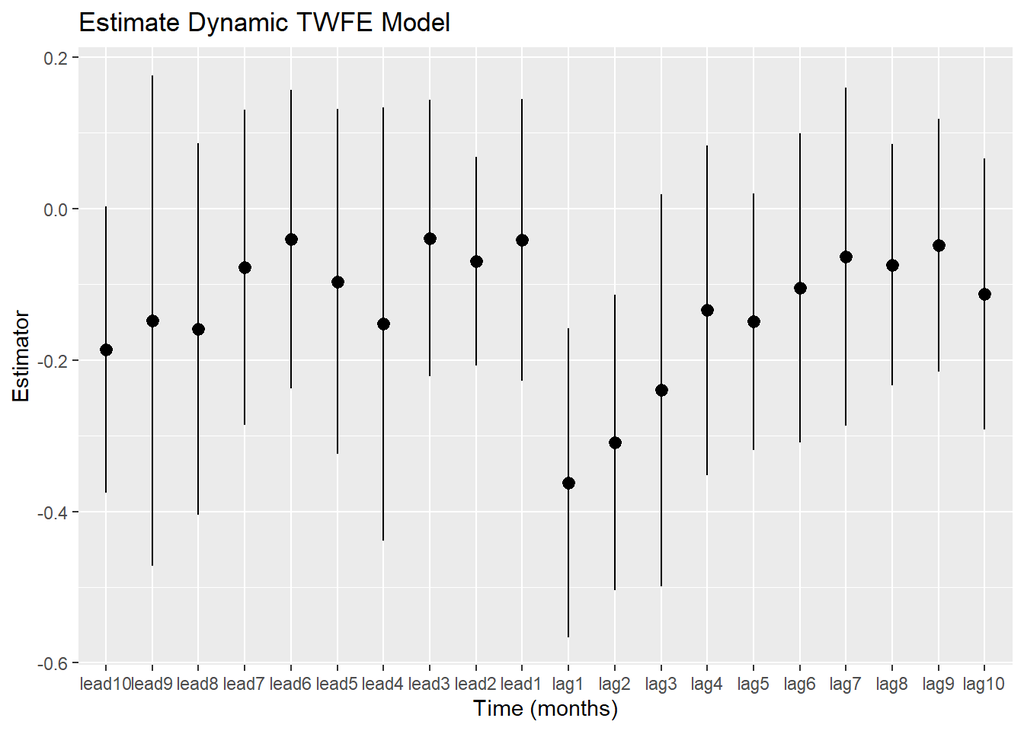

```r
# Saving model 6's results.
results <- tidy(model6)[c(2:21),]

# Create a plot for the time periods.
ggplot(results, aes(factor(term,level = results[,1]), estimate)) +
  geom_pointrange(aes(ymin=conf.low, ymax=conf.high))+
  labs(title = "Estimate Dynamic TWFE Model",x = "Time (months)",y = "Estimator")
```